# LEGO as an investment: does the 2015 evidence predict out of sample?

Hiro, Hendrik, Stefan

22 October 2026

# 0. Research question and data

Dobrynskaya and Kishilova (2022, *LEGO: The Toy of Smart Investors*, RIBF) find that retired LEGO sets earned about 11% a year on the secondary market between 1987 and 2015 and that the return of a set depends on its theme, size and year of release (Table 5 of the paper, R² = 0.47). Their regression is estimated and evaluated on the same sets, so it says which sets *did* appreciate, not which sets *will*. We ask two questions with the authors’ own published data (Mendeley Data v9hhs66vm3):

1. **Experiment 1, cross-sectional generalisation: do set characteristics generalise to sets a model has never seen?** Five-fold cross-validation by set: every model is estimated on 80% of the sets and evaluated on the other 20%. This tests generalisation across sets, not through time.
2. **Experiment 2, forward-return predictability: did the LEGO premium persist after 2015, and is the forward return predictable?** The authors’ second file gives monthly prices from January 2018 to April 2019 for the same sets, so we can compute the return an investor earned after December 2015 and test what information available in 2015 predicts it. The model is still estimated and scored on the same window, so this describes one period. Section 5 adds a forecast made in advance, as an investor could have done at the time.

We compare the models of the course: OLS, ridge, LASSO, elastic net, a regression tree, a random forest and XGBoost, scored by out-of-sample R², RMSE, rank correlation and hit ratios.

```r
library(tidyverse)      # data handling and plots
library(lubridate)      # year() and month()
library(readxl)         # read the Excel files
library(glmnet)         # ridge, LASSO and elastic net
library(rpart)          # regression tree
library(randomForest)   # random forest
library(sandwich)       # robust and clustered standard errors
library(knitr)          # kable() tables
has_xgb <- requireNamespace("xgboost", quietly = TRUE)   # TRUE if xgboost is installed
if (has_xgb) library(xgboost)                            # load it only if it is there

data_dir <- "."   # the two data files are in the same folder as this file

# read the 2015 file: one row per set, as in the paper
raw_2015 <- read_excel(file.path(data_dir, "DiB whole sample Dec 2015 prices.xlsx"),
                       sheet = "DATA", na = c("", "NA", "ND"))   # "ND" means no data
# short column names
names(raw_2015) <- c("id", "theme", "name", "year", "pieces", "minifigs",
                     "p_new_2015", "p_used_2015", "p_retail", "age", "size")

# count the sets that fail each filter below (shown in Section 0.1)
drop_counts <- raw_2015 %>%
  mutate(across(c(minifigs, p_new_2015, p_used_2015), ~ suppressWarnings(as.numeric(.x)))) %>%   # text to numbers
  summarise(`In the 2015 file` = n(),                                                 # all rows
            `No retail price` = sum(is.na(p_retail) | p_retail <= 0),                 # retail price missing or 0
            `New price 0 ("no sale") or missing` = sum(is.na(p_new_2015) | p_new_2015 <= 0),
            `Minifigures missing` = sum(is.na(minifigs)),
            `Released in 2015` = sum(year >= 2015, na.rm = TRUE))                     # would give a zero holding period

# build the 2015 sample
sets <- raw_2015 %>%
  mutate(across(c(minifigs, p_new_2015, p_used_2015), as.numeric),   # text to numbers
         id = as.character(id),                                      # id as text, to join with the 2018 file
         theme = relevel(factor(theme), ref = "Miscellaneous"),       # same reference theme as the paper
         size = factor(size, levels = 1:4),                          # size group: 1 = biggest, 4 = smallest
         year_f = factor(year),                                      # release year as dummies
         log_retail = log(p_retail)) %>%                             # log retail price
  filter(p_new_2015 > 0, p_retail > 0, !is.na(minifigs),             # a price of 0 means "no sale"
         year < 2015) %>%                                            # y15 below divides by 2015 - year
  droplevels() %>%                                                   # remove empty factor levels
  mutate(y15 = log(p_new_2015 / p_retail) / (2015 - year),           # annualised log return since release
         prem15 = log(p_new_2015 / p_retail),                        # total log premium over retail in Dec 2015
         log_p15 = log(p_new_2015))                                  # log price in Dec 2015

# read the monthly prices, January 2018 to April 2019
raw_1819 <- read_excel(file.path(data_dir, "DiB whole sample Jan 2018 - Apr 2019 prices.xlsx"),
                       skip = 1, na = c("", "NA", "ND"))             # row 1 is a title
month_cols <- names(raw_1819)[-(1:6)]                                # month headers are Excel date numbers
names(raw_1819)[-(1:6)] <- as.character(as.Date(as.numeric(month_cols), origin = "1899-12-30"))   # turn them into dates
prices_1819 <- raw_1819 %>%
  mutate(id = as.character(id)) %>%                                  # id as text
  select(id, matches("^20")) %>%                                     # keep id and the 16 month columns
  pivot_longer(-id, names_to = "date", values_to = "p") %>%          # one row per set and month
  mutate(date = as.Date(date), p = as.numeric(p)) %>%                # date and price as proper types
  filter(!is.na(p), p > 0)                                           # keep months with a price

# last observed price of each set (April 2019 for almost all sets)
p_end <- prices_1819 %>%
  group_by(id) %>%
  slice_max(date, n = 1, with_ties = FALSE) %>%                      # latest month per set
  ungroup() %>%
  transmute(id, date_end = date, p_end = p)
# price in January 2018
p_jan18 <- prices_1819 %>% filter(date == as.Date("2018-01-01")) %>% transmute(id, p_jan18 = p)

# forward returns after 2015
sets <- sets %>%
  left_join(p_end, by = "id") %>%                                    # add the last price
  left_join(p_jan18, by = "id") %>%                                  # add the January 2018 price
  mutate(h  = as.numeric(date_end - as.Date("2015-12-01")) / 365.25,   # years from Dec 2015 to the last price
         h2 = as.numeric(date_end - as.Date("2018-01-01")) / 365.25,   # years from Jan 2018 to the last price
         y_fwd  = log(p_end / p_new_2015) / h,                         # log return per year, Dec 2015 to 2019
         y_fwd2 = ifelse(h2 > 0.5, log(p_end / p_jan18) / h2, NA))     # log return per year, Jan 2018 to 2019

# helper: price of each set in one month, as a column with the given name
p_at <- function(d, name) prices_1819 %>% filter(date == as.Date(d)) %>% transmute(id, !!name := p)
sets <- sets %>% left_join(p_at("2019-04-01", "p_apr19"), by = "id")   # add the April 2019 price

# for the machine-learning models: pool rare themes and early years.
# the rule uses only the number of sets per level, not the returns
sets <- sets %>%
  mutate(theme_ml = fct_lump_min(theme, min = 15, other_level = "Other"),           # themes with < 15 sets become "Other"
         year_ml  = factor(ifelse(year < 1995, "pre-1995", as.character(year))),   # years before 1995 in one group
         pieces_sq = pieces^2)                                                       # pieces squared

# small helpers for numbers in the text
f3  <- function(x) formatC(x, format = "f", digits = 3)                       # 3 decimals
f2  <- function(x) formatC(x, format = "f", digits = 2)                       # 2 decimals
pct <- function(x) paste0(formatC(100 * x, format = "f", digits = 1), "%")    # percent with 1 decimal
num <- function(x) format(x, big.mark = ",")                                  # thousands separator
# p-value as text; with B bootstrap draws the smallest possible p is 1 / (B + 1)
pfmt <- function(p, B = 999) ifelse(p <= 1 / (B + 1) + 1e-12, "&le; 0.001",
                                     ifelse(p < 0.001, "< 0.001", paste("=", formatC(p, format = "f", digits = 3))))
SEED <- 42   # random seed used everywhere
```

```r
# simple return of each set from Dec 2015 to Apr 2019
head_fwd <- sets %>% filter(!is.na(p_apr19)) %>% transmute(R = p_apr19 / p_new_2015 - 1)
head_median <- median(head_fwd$R)   # the typical set
head_mean   <- mean(head_fwd$R)     # equal-weighted portfolio of all sets
head_up     <- mean(head_fwd$R > 0) # share of sets that gained
```

The sample: 2,300 retired sets with a retail price and a December 2015 secondary-market price

| Variable | Sets | Mean | Median | SD | Share > 0 |
| --- | --- | --- | --- | --- | --- |
| Return since release to Dec 2015 (y15, log, p.a.) | 2300 | 0.148 | 0.114 | 0.186 | 0.904 |
| Premium over retail in Dec 2015 (prem15, log) | 2300 | 0.747 | 0.675 | 0.632 | 0.904 |
| Forward return Dec 2015 to Apr 2019 (y_fwd, log, p.a.) | 2271 | -0.029 | -0.017 | 0.153 | 0.439 |
| Forward return Jan 2018 to Apr 2019 (y_fwd2, log, p.a.) | 2205 | -0.036 | -0.023 | 0.195 | 0.425 |

**Answer.** The sample is the paper’s: 2,300 retired sets released between 1981 and 2014. Up to December 2015 the average set earned 14.8% a year in log terms (median 11.4%) and 90.4% of sets were above their retail price. The paper reports about 11% a year; its return definition may differ from our mean annualised log return, and our median is the closer figure. After 2015 the picture changes. From December 2015 to April 2019 the median set’s price changed by -5.5% and an equal-weighted portfolio of all sets by 2.7%, in simple returns before costs; 43.9% of sets gained. The models below use annualised log returns, whose mean (-2.9% a year) lies below the log of the average return, so it looks worse than the portfolio figure. Both describe the same prices; the headline figures in this report are the simple returns.

## 0.1 Data source, comparability and dropped sets

**Source.** The sheet “About the sample” in the 2015 file describes BrickPicker’s price guide: eBay sold auctions, bought via Terapeak, “aggregate[d] into our monthly Price Guide”; values “are approximate ones and are several months old”. The prices are therefore monthly aggregates of realised eBay sales, not single trades or asking prices. The 2018-2019 file does not name its source.

**Are the two files comparable?** If the 2018-2019 file used another source or another condition (for example used instead of new sets), every forward return would shift by the same amount and look like a crash. We check this directly.

```r
# sets that are in both files, with theme and year as written in the 2018 file
cmp <- sets %>%
  filter(!is.na(p_jan18)) %>%                                        # sets with a January 2018 price
  inner_join(raw_1819 %>% transmute(id = as.character(id), theme_1819 = theme, year_1819 = `year of release`),
             by = "id")
# checks: same sets, and new or used condition
cmp_stats <- tibble(
  Check = c("Sets in both files", "Same theme in both files", "Same release year in both files",
            "Median log change, Dec 2015 new price to Jan 2018", "Median log change, Dec 2015 used price to Jan 2018",
            "Correlation of log prices, Dec 2015 new vs Jan 2018"),
  Value = c(nrow(cmp),
            mean(cmp$theme_1819 == as.character(cmp$theme)),                 # share with the same theme
            mean(cmp$year_1819 == cmp$year),                                 # share with the same year
            median(log(cmp$p_jan18 / cmp$p_new_2015)),                       # near 0 if 2018 holds new prices
            median(log(cmp$p_jan18 / cmp$p_used_2015), na.rm = TRUE),        # near 0 if 2018 holds used prices
            cor(log(cmp$p_jan18), log(cmp$p_new_2015))))
```

Do the 2015 and 2018-2019 files describe the same sets in the same condition?

| Check | Value |
| --- | --- |
| Sets in both files | 2205.000 |
| Same theme in both files | 1.000 |
| Same release year in both files | 1.000 |
| Median log change, Dec 2015 new price to Jan 2018 | -0.015 |
| Median log change, Dec 2015 used price to Jan 2018 | 0.537 |
| Correlation of log prices, Dec 2015 new vs Jan 2018 | 0.908 |

Why sets leave the sample (a set can fail several checks)

| Reason | Sets |
| --- | --- |
| In the 2015 file | 2322 |
| No retail price | 17 |
| New price 0 (“no sale”) or missing | 4 |
| Minifigures missing | 3 |
| Released in 2015 | 0 |
| Kept in the 2015 sample | 2300 |
| Of these, no Jan 2018 price | 95 |
| Of these, no 2018-2019 price at all | 29 |

# 1. Replication of the paper’s regression (Table 5)

```r
# the paper's regression: total log premium on theme, size and year dummies
fit_paper <- lm(log(p_new_2015 / p_retail) ~ theme + size + year_f, data = sets)
```

Replication of Table 5

| Coefficient | Our estimate | Paper, Table 5 | Difference |
| --- | --- | --- | --- |
| Batman theme | 0.4501 | 0.4484 | 0.0017 |
| Discovery theme | 0.6145 | 0.6124 | 0.0021 |
| Size group 2 (vs 1) | -0.2268 | -0.2438 | 0.0170 |
| R squared | 0.4701 | 0.4695 | 0.0006 |

**Answer.** The coefficients and the R² are close to the paper’s: the largest difference in the table is 0.017. Small differences can come from the sets with missing values that we drop. We therefore start from the authors’ sample and specification. Note what the R² of 0.47 means: the regression has 77 parameters for 2,300 sets, all fitted and evaluated on the same data. The next section asks how much of this survives on sets the model has not seen.

# 2. Experiment 1: cross-sectional generalisation (unseen sets)

```r
# feature sets. Dummies are built once on all sets, so every fold has the same columns
f_paper <- ~ theme_ml + size + year_ml                                       # the paper's variables
f_full  <- ~ theme_ml + size + year_ml + pieces + pieces_sq + minifigs + log_retail   # plus set characteristics
f_mom   <- ~ theme_ml + size + year_ml + pieces + pieces_sq + minifigs + log_retail + prem15 + log_p15 + y15   # plus 2015 prices
rhs_full <- c("theme_ml", "size", "year_ml", "pieces", "minifigs", "log_retail")   # same features for the tree models
rhs_mom  <- c(rhs_full, "prem15", "log_p15", "y15")

# fit one model on the training rows and predict the test rows
fit_predict <- function(model, X_tr, y_tr, X_te, df_tr, df_te, rhs, seed = 42){
  set.seed(seed)                                                       # same seed for every model
  switch(model,
    "Naive (mean)"  = rep(mean(y_tr), nrow(X_te)),                     # predict the training mean for every set
    "OLS"           = { b <- coef(lm.fit(cbind(1, X_tr), y_tr))        # least squares with an intercept
                        b[is.na(b)] <- 0                               # collinear columns get weight 0
                        as.numeric(cbind(1, X_te) %*% b) },            # predictions for the test rows
    "Ridge"         = as.numeric(predict(cv.glmnet(X_tr, y_tr, alpha = 0),   X_te, s = "lambda.min")),   # penalty chosen by CV
    "LASSO"         = as.numeric(predict(cv.glmnet(X_tr, y_tr, alpha = 1),   X_te, s = "lambda.min")),
    "Elastic net"   = as.numeric(predict(cv.glmnet(X_tr, y_tr, alpha = 0.5), X_te, s = "lambda.min")),
    "Tree"          = predict(rpart(reformulate(rhs, "y"), data = df_tr,
                                    minbucket = 30, cp = 0.001, maxdepth = 4, xval = 0), df_te),    # small tree, settings from the course
    "Random forest" = predict(randomForest(reformulate(rhs, "y"), data = df_tr,
                                           ntree = 300, mtry = max(2, floor(length(rhs) / 3)),   # 300 trees, 1/3 of features per split
                                           nodesize = 10, sampsize = floor(0.7 * nrow(df_tr)), replace = FALSE), df_te),
    "XGBoost"       = { if (!has_xgb) return(rep(NA_real_, nrow(X_te)))   # skip if xgboost is not installed
                        fit <- xgb.train(params = list(objective = "reg:squarederror", eta = 0.05, max_depth = 3,
                                                       subsample = 0.8, colsample_bytree = 0.8, lambda = 1, nthread = 2),
                                         data = xgb.DMatrix(X_tr, label = y_tr), nrounds = 300, verbose = 0)
                        predict(fit, X_te) })
}

# out-of-fold predictions for one target and one feature set.
# group = NULL gives random folds by set; group = "theme" or "year" keeps each group in one fold
cv_models <- function(df, target, formula_x, rhs, k = 5, seed = 42, group = NULL,
                      models = c("Naive (mean)", "OLS", "Ridge", "LASSO", "Elastic net", "Tree", "Random forest", "XGBoost")){
  df <- df %>%
    filter(!is.na(.data[[target]]), if_all(all.vars(formula_x), ~ !is.na(.x))) %>%   # rows with no missing values
    mutate(y = .data[[target]])                                                      # target column called y
  X <- model.matrix(formula_x, data = df)[, -1, drop = FALSE]        # dummy matrix without the intercept
  set.seed(seed)
  if (is.null(group)) {
    fold <- sample(rep(1:k, length.out = nrow(df)))                  # each set gets a random fold
  } else {
    g <- unique(df[[group]])                                         # list of groups
    fold <- sample(rep(1:k, length.out = length(g)))[match(df[[group]], g)]   # each group gets a random fold
  }
  lapply(models, function(m){
    pred <- rep(NA_real_, nrow(df))                                  # empty vector for the predictions
    for (f in 1:k) {
      tr <- fold != f                                                # training rows: all other folds
      pred[!tr] <- fit_predict(m, X[tr, , drop = FALSE], df$y[tr],   # fit on them and predict fold f
                               X[!tr, , drop = FALSE], df[tr, ], df[!tr, ], rhs, seed = seed + f)
    }
    tibble(Model = m, id = df$id, y = df$y, pred = pred)             # one row per set
  }) %>%
    bind_rows() %>%                                                  # all models in one table
    filter(!is.na(pred))                                             # drops XGBoost if it is not installed
}

# scores of the out-of-fold predictions, one row per model
score <- function(oof){
  oof %>% group_by(Model) %>%
    summarise(`OOS R2`     = 1 - mean((y - pred)^2) / mean((y - mean(y))^2),   # out-of-sample R squared
              RMSE         = sqrt(mean((y - pred)^2)),
              `Rank corr.` = if (sd(pred) == 0) NA else cor(pred, y, method = "spearman"),
              `Median hit` = if (sd(pred) == 0) NA else mean((pred > median(pred)) == (y > median(y))),   # same side of the median
              `Sign hit`   = mean(pred * y > 0),                                # same sign as the true value
              `Share y > 0` = mean(y > 0),                                      # compare the sign hit with this
              .groups = "drop") %>%
    arrange(RMSE)                                                               # best model first
}
```

```r
# paper's variables: only the naive model and OLS
oof_paper <- cv_models(sets, "y15", f_paper, c("theme_ml", "size", "year_ml"), models = c("Naive (mean)", "OLS"))
# paper's variables plus characteristics: all models
oof_full  <- cv_models(sets, "y15", f_full, rhs_full)

# in-sample R squared of the same two regressions, for comparison
r2_in <- c(paper = summary(lm(y15 ~ theme_ml + size + year_ml, sets))$r.squared,
           full  = summary(lm(y15 ~ theme_ml + size + year_ml + pieces + pieces_sq + minifigs + log_retail, sets))$r.squared)

# one results table
res2 <- bind_rows(score(oof_paper) %>% mutate(Features = "Paper (theme, size, year)"),
                  score(oof_full)  %>% mutate(Features = "Paper + pieces, minifigures, retail price")) %>%
  select(Features, everything())
```

Held-out sets (5-fold CV by set). Target: annualised return since release to Dec 2015

| Features | Model | OOS R2 | RMSE | Rank corr. | Median hit | Sign hit | Share y > 0 |
| --- | --- | --- | --- | --- | --- | --- | --- |
| Paper (theme, size, year) | OLS | 0.226 | 0.164 | 0.456 | 0.678 | 0.880 | 0.904 |
| Paper (theme, size, year) | Naive (mean) | -0.001 | 0.186 | -0.006 | 0.504 | 0.904 | 0.904 |
| Paper + pieces, minifigures, retail price | XGBoost | 0.486 | 0.133 | 0.596 | 0.710 | 0.911 | 0.904 |
| Paper + pieces, minifigures, retail price | Random forest | 0.486 | 0.133 | 0.640 | 0.735 | 0.914 | 0.904 |
| Paper + pieces, minifigures, retail price | Tree | 0.364 | 0.148 | 0.484 | 0.646 | 0.913 | 0.904 |
| Paper + pieces, minifigures, retail price | LASSO | 0.297 | 0.156 | 0.523 | 0.681 | 0.871 | 0.904 |
| Paper + pieces, minifigures, retail price | Elastic net | 0.297 | 0.156 | 0.523 | 0.683 | 0.872 | 0.904 |
| Paper + pieces, minifigures, retail price | Ridge | 0.296 | 0.156 | 0.528 | 0.689 | 0.869 | 0.904 |
| Paper + pieces, minifigures, retail price | OLS | 0.293 | 0.156 | 0.529 | 0.688 | 0.862 | 0.904 |
| Paper + pieces, minifigures, retail price | Naive (mean) | -0.001 | 0.186 | -0.006 | 0.504 | 0.904 | 0.904 |

**Answer.** Our target is the *annualised* return, so the R² values are lower than the paper’s 0.47, which is for the cumulative return where the year dummies also absorb the holding period (in sample: 26.0% for the paper’s features, 33.1% with the extra features). On held-out sets the OLS with the paper’s features keeps an out-of-sample R² of 0.226, so most of the explanatory power generalises: theme and year of release really do separate sets that appreciated from sets that did not. Adding pieces, minifigures and the retail price raises the out-of-sample R² of OLS to 0.293. The best model is the **XGBoost** with an out-of-sample R² of 0.486 and a rank correlation of 0.596; the rank correlations of the other models lie between 0.484 and 0.640. Against OLS, the best penalised regression changes the out-of-sample R² by 0.005 and the best tree model by 0.193. (The penalised models choose their penalty by cross-validation inside each training fold; the tree, random forest and XGBoost use fixed settings from the course, so the model comparison is indicative, not a tuned contest.) The sign hit ratio is not informative here: 90.4% of sets have a positive return, so any model that predicts a positive return scores about that much. These folds hold out single sets, which still share theme and release year with many training sets; Section 2.2 holds out whole themes and whole years.

## 2.1 Age as a number, target: cumulative premium (prem15)

The cross-validation above scores predictions. Here we fit two OLS regressions once on all sets and test each coefficient. The year-of-release dummies are replaced by **age as one number** (years since release, the `age` column of the data file), so the model has one slope for “one more year of age”. The target is the **cumulative** log premium over retail, `prem15 = log(p_new_2015 / p_retail)`, because the annualised return `y15` is divided by age and would make older sets look worse by construction. Stars use classical OLS standard errors; the second table repeats the test for the non-dummy variables with heteroskedasticity-robust (HC1) standard errors. The LASSO charts show how each coefficient shrinks to zero as the penalty grows.

```r
sets <- sets %>% mutate(age = as.numeric(age))   # age in years, from the data file

# one OLS fit to one row per coefficient: estimate, standard error, t, p and stars
coef_table <- function(fit, se = c("classical", "HC1")){
  se <- match.arg(se)                                                # "classical" or "HC1"
  b  <- coef(fit)                                                    # all coefficients
  aliased <- names(b)[is.na(b)]                                      # collinear columns (lm gives NA)
  b  <- b[!is.na(b)]                                                 # keep the estimated ones
  V  <- if (se == "classical") vcov(fit) else vcovHC(fit, type = "HC1")   # covariance matrix
  s  <- sqrt(diag(V))[names(b)]                                      # standard errors
  t  <- b / s                                                        # t-statistics
  p  <- 2 * pt(-abs(t), df = df.residual(fit))                       # two-sided p-values
  bind_rows(tibble(Term = names(b), Estimate = b, SE = s, t = t, p = p),
            tibble(Term = aliased, Estimate = NA_real_, SE = NA_real_, t = NA_real_, p = NA_real_)) %>%
    mutate(Sig. = case_when(is.na(p) ~ "aliased", p < 0.01 ~ "***", p < 0.05 ~ "**", p < 0.1 ~ "*", TRUE ~ ""))
}

# several fits to one table: each cell is "estimate stars (SE)", fit statistics at the bottom
reg_table <- function(fits, digits = 3){
  fmt <- function(x) formatC(x, format = "g", digits = digits)       # "g" keeps very small numbers readable
  cells <- imap(fits, function(fit, nm){
    coef_table(fit) %>%
      transmute(Term, !!nm := ifelse(is.na(Estimate), "aliased",
                                     paste0(fmt(Estimate), Sig., " (", fmt(SE), ")")))
  }) %>% reduce(full_join, by = "Term")                              # one column per model
  terms <- unique(unlist(map(fits, ~ names(coef(.x)))))              # coefficient order as in the models
  cells <- cells %>% slice(match(terms, Term)) %>% mutate(across(-Term, ~ replace_na(.x, "")))
  stats <- map_dfc(fits, function(fit){
    s <- summary(fit)
    c(nobs(fit),                                                     # number of sets
      formatC(s$r.squared, format = "f", digits = 3),
      formatC(s$adj.r.squared, format = "f", digits = 3),
      formatC(pf(s$fstatistic[1], s$fstatistic[2], s$fstatistic[3], lower.tail = FALSE), format = "e", digits = 2))   # F-test p
  })
  bind_rows(cells, bind_cols(Term = c("Sets (N)", "R squared", "Adjusted R squared", "F-test p-value"), stats))
}

# non-dummy variables only: classical and robust (HC1) tests side by side
robust_check <- function(fits, keep){
  imap_dfr(fits, function(fit, nm){
    full_join(coef_table(fit, "classical") %>% select(Term, Estimate, t, p, Sig.),
              coef_table(fit, "HC1") %>% select(Term, `t (HC1)` = t, `p (HC1)` = p, `Sig. (HC1)` = Sig.),
              by = "Term") %>%
      filter(Term %in% keep) %>%                                     # keep the listed variables
      mutate(Model = nm, .before = 1,
             Estimate = formatC(Estimate, format = "g", digits = 3))   # as text, so kable does not round small values to 0
  })
}
cont_vars <- c("(Intercept)", "age", "pieces", "pieces_sq", "minifigs", "log_retail", "prem15", "log_p15", "y15")
```

```r
# LASSO path on all sets. Predictors are standardised, so the betas can be compared.
# lambda is chosen by 10-fold CV; the dashed lines show lambda.min and lambda.1se
lasso_path <- function(df, target, formula_x, title, n_label = 8, seed = 42){
  df <- df %>% filter(!is.na(.data[[target]]), if_all(all.vars(formula_x), ~ !is.na(.x)))   # same rows in X and y
  X  <- scale(model.matrix(formula_x, data = df)[, -1, drop = FALSE])   # standardised predictors
  set.seed(seed)
  cv  <- cv.glmnet(X, df[[target]], alpha = 1)                       # LASSO with cross-validation
  fit <- cv$glmnet.fit                                               # the full path
  path <- as.matrix(fit$beta) %>%                                    # one column per lambda
    as_tibble(rownames = "Variable") %>%
    pivot_longer(-Variable, names_to = "step", values_to = "beta") %>%   # long format for ggplot
    mutate(lambda = fit$lambda[as.integer(sub("^s", "", step)) + 1])     # lambda value of each step
  # colour the variables that stay in the model longest
  top <- path %>% group_by(Variable) %>%
    summarise(enter = max(c(0, lambda[beta != 0])),                  # largest lambda with a non-zero beta
              size  = abs(beta[which.min(lambda)]), .groups = "drop") %>%   # beta at the smallest lambda, to break ties
    arrange(desc(enter), desc(size)) %>% slice_head(n = n_label) %>% pull(Variable)
  path <- path %>% mutate(Label = ifelse(Variable %in% top, Variable, "Other"),
                          Label = factor(Label, levels = c(top, "Other")))
  n_sel <- sum(coef(cv, s = "lambda.min")[-1] != 0)                  # variables kept at lambda.min
  p <- ggplot(path, aes(x = lambda, y = beta, group = Variable, colour = Label)) +
    geom_hline(yintercept = 0, colour = "grey60") +                  # zero line
    geom_line(data = filter(path, Label == "Other"), linewidth = 0.3) +   # other variables, thin grey
    geom_line(data = filter(path, Label != "Other"), linewidth = 0.8) +   # top variables, coloured
    geom_vline(xintercept = c(cv$lambda.min, cv$lambda.1se), linetype = 2) +
    scale_x_log10() +                                                # lambda on a log scale
    scale_colour_manual(values = c(setNames(scales::hue_pal()(length(top)), top), Other = "grey80"),
                        breaks = c(top, "Other")) +
    labs(title = title,
         subtitle = paste0("Dashed: lambda.min = ", signif(cv$lambda.min, 3), " (", n_sel, " of ", ncol(X),
                           " variables kept) and lambda.1se = ", signif(cv$lambda.1se, 3)),
         x = "Lambda (penalty, log scale)", y = "Standardised coefficient (beta)", colour = NULL) +
    theme_light()
  list(plot = p, cv = cv)                                            # return the plot and the CV fit
}
```

```r
# age as one number instead of year dummies
f_paper_agen <- ~ theme_ml + size + age
f_full_agen  <- ~ theme_ml + size + age + pieces + pieces_sq + minifigs + log_retail

# two OLS fits on all sets, target prem15
fits2_agen <- list(`Theme, size, age`                                     = lm(update(f_paper_agen, prem15 ~ .), data = sets),
                   `Theme, size, age + pieces, minifigures, retail price` = lm(update(f_full_agen,  prem15 ~ .), data = sets))
```

OLS on all sets. Target: cumulative log premium over retail in Dec 2015 (prem15). Estimate (classical SE); *** p < 0.01, ** p < 0.05, * p < 0.1. Reference levels: theme Miscellaneous, size group 1

| Term | Theme, size, age | Theme, size, age + pieces, minifigures, retail price |
| --- | --- | --- |
| (Intercept) | 0.175 (0.11) | 1.08*** (0.159) |
| theme_mlAdvanced models | 0.477*** (0.134) | 0.427*** (0.127) |
| theme_mlAgents | 0.101 (0.146) | 0.174 (0.137) |
| theme_mlArchitecture | -0.0272 (0.135) | 0.116 (0.127) |
| theme_mlAtlantis | -0.261* (0.142) | -0.252* (0.132) |
| theme_mlBatman | 0.55*** (0.126) | 0.586*** (0.118) |
| theme_mlBionicle | 0.0703 (0.0996) | 0.0513 (0.0926) |
| theme_mlCars | 0.00401 (0.14) | 0.0676 (0.13) |
| theme_mlCastle | -0.0633 (0.104) | 0.0128 (0.0983) |
| theme_mlCity | 0.101 (0.0984) | 0.184** (0.0918) |
| theme_mlCreator | 0.102 (0.103) | 0.00858 (0.0967) |
| theme_mlFriends | 0.128 (0.107) | 0.105 (0.0998) |
| theme_mlHarry Potter | 0.459*** (0.117) | 0.577*** (0.109) |
| theme_mlHero factory | 0.227** (0.107) | 0.291*** (0.0997) |
| theme_mlIndiana Jones | 0.592*** (0.155) | 0.701*** (0.145) |
| theme_mlLegends of China | -0.0882 (0.109) | -0.0171 (0.101) |
| theme_mlLord of the Rings | -0.108 (0.127) | -0.0325 (0.119) |
| theme_mlNinjago | 0.0733 (0.106) | 0.122 (0.0987) |
| theme_mlPirates | -0.117 (0.119) | 0.0576 (0.112) |
| theme_mlPower miners | 0.35** (0.154) | 0.516*** (0.143) |
| theme_mlSeasonal | 0.399*** (0.112) | 0.22** (0.105) |
| theme_mlSpace | -0.205* (0.112) | -0.163 (0.105) |
| theme_mlStar Wars | 0.0971 (0.0976) | 0.156* (0.0911) |
| theme_mlSuper Heroes | 0.446*** (0.119) | 0.436*** (0.111) |
| theme_mlTechnic | -0.0477 (0.104) | 0.0194 (0.0981) |
| theme_mlTeenage mutant ninja turtle | -0.184 (0.154) | -0.14 (0.144) |
| theme_mlThe Lego movie | -0.0384 (0.149) | -0.06 (0.139) |
| theme_mlTrains | 0.257* (0.135) | 0.449*** (0.126) |
| theme_mlOther | 0.116 (0.103) | 0.183* (0.0957) |
| size2 | -0.163** (0.065) | -0.00186 (0.0872) |
| size3 | -0.148** (0.0627) | -0.00282 (0.113) |
| size4 | 0.099* (0.0594) | -0.0458 (0.135) |
| age | 0.0662*** (0.00255) | 0.0593*** (0.0024) |
| pieces |  | 0.00057*** (0.000141) |
| pieces_sq |  | -6.55e-08** (2.58e-08) |
| minifigs |  | -0.00718 (0.00551) |
| log_retail |  | -0.331*** (0.0213) |
| Sets (N) | 2300 | 2300 |
| R squared | 0.406 | 0.489 |
| Adjusted R squared | 0.398 | 0.481 |
| F-test p-value | 1.27e-229 | 3.39e-298 |

Non-dummy variables: classical vs heteroskedasticity-robust (HC1) tests

| Model | Term | Estimate | t | p | Sig. | t (HC1) | p (HC1) | Sig. (HC1) |
| --- | --- | --- | --- | --- | --- | --- | --- | --- |
| Theme, size, age | (Intercept) | 0.175 | 1.593 | 0.111 |  | 1.695 | 0.090 | * |
| Theme, size, age | age | 0.0662 | 25.954 | 0.000 | *** | 23.358 | 0.000 | *** |
| Theme, size, age + pieces, minifigures, retail price | (Intercept) | 1.08 | 6.789 | 0.000 | *** | 6.663 | 0.000 | *** |
| Theme, size, age + pieces, minifigures, retail price | age | 0.0593 | 24.712 | 0.000 | *** | 21.006 | 0.000 | *** |
| Theme, size, age + pieces, minifigures, retail price | pieces | 0.00057 | 4.047 | 0.000 | *** | 3.151 | 0.002 | *** |
| Theme, size, age + pieces, minifigures, retail price | pieces_sq | -6.55e-08 | -2.536 | 0.011 | ** | -1.552 | 0.121 |  |
| Theme, size, age + pieces, minifigures, retail price | minifigs | -0.00718 | -1.303 | 0.193 |  | -1.072 | 0.284 |  |
| Theme, size, age + pieces, minifigures, retail price | log_retail | -0.331 | -15.552 | 0.000 | *** | -12.911 | 0.000 | *** |

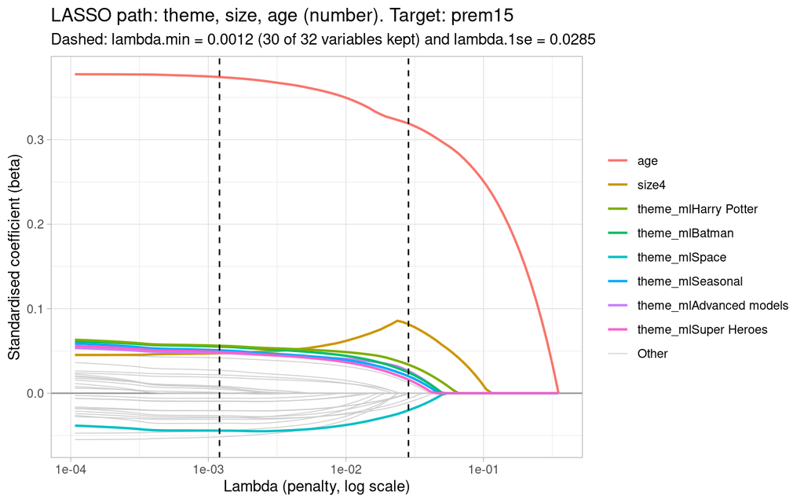

```r
# LASSO paths for the two feature sets
lp2_agen_paper <- lasso_path(sets, "prem15", f_paper_agen, "LASSO path: theme, size, age (number). Target: prem15")
lp2_agen_full  <- lasso_path(sets, "prem15", f_full_agen,  "LASSO path: theme, size, age (number) + pieces, minifigures, retail price. Target: prem15")
lp2_agen_paper$plot
```

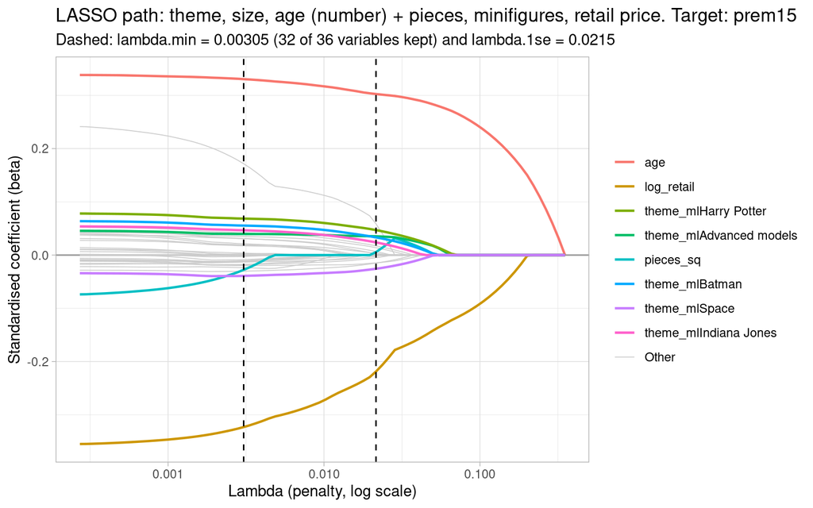

```r
lp2_agen_full$plot
```

**How to read the age coefficient.** The target is a log, so a coefficient of 0.05 means about 5% more premium over retail for each extra year of age, with theme and size held fixed. It is one average slope: it assumes each extra year adds the same amount.

## 2.2 Grouped cross-validation: unseen themes and unseen years

Random folds hold out single sets, but a held-out set shares its theme and release year with many training sets. So the model only has to learn theme and year averages. A stricter test holds out *whole groups* (Roberts et al. 2017):

- **Unseen themes.** Every set of a theme is in the same fold. A theme dummy cannot carry over to a theme the model has never seen, so the features here are size, release year, pieces, minifigures and retail price.
- **Unseen years.** Every set of a release year is in the same fold. Year dummies cannot carry over either, so age enters as a number, which can extrapolate, together with theme, size, pieces, minifigures and retail price.

Each grouped run is compared with random folds on the *same* features, so the difference shows the cost of the grouping alone.

```r
# features for the unseen-theme test: no theme dummies
f_no_theme   <- ~ size + year_ml + pieces + pieces_sq + minifigs + log_retail
rhs_no_theme <- c("size", "year_ml", "pieces", "minifigs", "log_retail")
# features for the unseen-year test: age as a number instead of year dummies
f_no_year    <- ~ theme_ml + size + age + pieces + pieces_sq + minifigs + log_retail
rhs_no_year  <- c("theme_ml", "size", "age", "pieces", "minifigs", "log_retail")
grp_models   <- c("Naive (mean)", "OLS", "LASSO", "Random forest", "XGBoost")

# four runs: random and grouped folds for each question
grp_runs <- list(
  list(Question = "Unseen themes", Folds = "Random sets",  f = f_no_theme, rhs = rhs_no_theme, group = NULL),
  list(Question = "Unseen themes", Folds = "Whole themes", f = f_no_theme, rhs = rhs_no_theme, group = "theme"),
  list(Question = "Unseen years",  Folds = "Random sets",  f = f_no_year,  rhs = rhs_no_year,  group = NULL),
  list(Question = "Unseen years",  Folds = "Whole years",  f = f_no_year,  rhs = rhs_no_year,  group = "year"))

# run them and stack the scores
res2_grp <- map_dfr(grp_runs, function(r)
  score(cv_models(sets, "y15", r$f, r$rhs, group = r$group, models = grp_models)) %>%
    mutate(Question = r$Question, Folds = r$Folds)) %>%
  select(Question, Folds, Model, `OOS R2`, RMSE, `Rank corr.`)

# OLS results side by side, used in the text
grp_ols <- res2_grp %>% filter(Model == "OLS") %>% select(Question, Folds, `OOS R2`) %>%
  pivot_wider(names_from = Folds, values_from = `OOS R2`)
# best model in each grouped run
grp_best <- res2_grp %>% filter(Model != "Naive (mean)", Folds %in% c("Whole themes", "Whole years")) %>%
  group_by(Question) %>% slice_max(`OOS R2`, n = 1) %>% ungroup()
```

Target: annualised return since release to Dec 2015. Random folds vs whole themes or whole years held out, same features within each question

| Question | Folds | Model | OOS R2 | RMSE | Rank corr. |
| --- | --- | --- | --- | --- | --- |
| Unseen themes | Random sets | XGBoost | 0.472 | 0.135 | 0.558 |
| Unseen themes | Random sets | Random forest | 0.456 | 0.137 | 0.570 |
| Unseen themes | Random sets | LASSO | 0.253 | 0.161 | 0.465 |
| Unseen themes | Random sets | OLS | 0.251 | 0.161 | 0.472 |
| Unseen themes | Random sets | Naive (mean) | -0.001 | 0.186 | -0.006 |
| Unseen themes | Whole themes | Random forest | 0.401 | 0.144 | 0.511 |
| Unseen themes | Whole themes | XGBoost | 0.400 | 0.144 | 0.512 |
| Unseen themes | Whole themes | LASSO | 0.237 | 0.162 | 0.447 |
| Unseen themes | Whole themes | OLS | 0.231 | 0.163 | 0.455 |
| Unseen themes | Whole themes | Naive (mean) | -0.009 | 0.187 | -0.145 |
| Unseen years | Random sets | XGBoost | 0.499 | 0.132 | 0.627 |
| Unseen years | Random sets | Random forest | 0.480 | 0.134 | 0.637 |
| Unseen years | Random sets | LASSO | 0.239 | 0.162 | 0.525 |
| Unseen years | Random sets | OLS | 0.234 | 0.163 | 0.524 |
| Unseen years | Random sets | Naive (mean) | -0.001 | 0.186 | -0.006 |
| Unseen years | Whole years | Random forest | 0.164 | 0.170 | 0.502 |
| Unseen years | Whole years | LASSO | 0.144 | 0.172 | 0.455 |
| Unseen years | Whole years | OLS | 0.135 | 0.173 | 0.456 |
| Unseen years | Whole years | XGBoost | 0.092 | 0.177 | 0.483 |
| Unseen years | Whole years | Naive (mean) | -0.021 | 0.188 | -0.122 |

**Answer.** Holding out whole themes, OLS reaches an out-of-sample R² of 0.231 against 0.251 with random folds on the same features. Holding out whole release years, it reaches 0.135 against 0.234. The best model on unseen themes is Random forest (0.401) and on unseen years Random forest (0.164). Some explanatory power survives even when the model has never seen the theme or the year, so the paper’s result is not only an artefact of in-sample fitting. A new LEGO set usually belongs to an existing theme, so the unseen-theme test is stricter than most practical uses. Release years carry over less well than themes. Two possible reasons, which we do not test: each release cohort meets its own market (collector demand, production runs and retirement timing at the time), and the target is the annualised return since release, so the release year also fixes the holding period and makes the year effect non-linear in age; an unseen year forces the model to extrapolate it.

# 3. Experiment 2: forward-return predictability, 2015 to 2019

```r
oof_f_char <- cv_models(sets, "y_fwd", f_full, rhs_full)                  # characteristics only
oof_f_mom  <- cv_models(sets, "y_fwd", f_mom,  rhs_mom)                   # plus the 2015 price, premium and return
oof_f_y15  <- cv_models(sets, "y_fwd", ~ y15, "y15", models = c("OLS"))   # the 2015 return alone

# one results table
res3 <- bind_rows(score(oof_f_char) %>% mutate(Features = "Characteristics"),
                  score(oof_f_mom)  %>% mutate(Features = "Characteristics + 2015 price, premium, return"),
                  score(oof_f_y15)  %>% mutate(Features = "2015 return only")) %>%
  select(Features, everything())
```

Held-out sets. Target: forward return December 2015 to April 2019 (log, p.a.)

| Features | Model | OOS R2 | RMSE | Rank corr. | Median hit | Sign hit | Share y > 0 |
| --- | --- | --- | --- | --- | --- | --- | --- |
| Characteristics | Random forest | 0.210 | 0.136 | 0.507 | 0.692 | 0.690 | 0.439 |
| Characteristics | XGBoost | 0.202 | 0.136 | 0.496 | 0.684 | 0.666 | 0.439 |
| Characteristics | Ridge | 0.179 | 0.138 | 0.434 | 0.665 | 0.640 | 0.439 |
| Characteristics | LASSO | 0.178 | 0.139 | 0.432 | 0.662 | 0.642 | 0.439 |
| Characteristics | Elastic net | 0.178 | 0.139 | 0.432 | 0.664 | 0.641 | 0.439 |
| Characteristics | OLS | 0.173 | 0.139 | 0.431 | 0.663 | 0.642 | 0.439 |
| Characteristics | Tree | 0.137 | 0.142 | 0.390 | 0.627 | 0.621 | 0.439 |
| Characteristics | Naive (mean) | 0.000 | 0.153 | -0.015 | 0.486 | 0.559 | 0.439 |
| Characteristics + 2015 price, premium, return | Random forest | 0.396 | 0.119 | 0.659 | 0.744 | 0.738 | 0.439 |
| Characteristics + 2015 price, premium, return | XGBoost | 0.386 | 0.120 | 0.644 | 0.731 | 0.732 | 0.439 |
| Characteristics + 2015 price, premium, return | LASSO | 0.372 | 0.121 | 0.615 | 0.725 | 0.717 | 0.439 |
| Characteristics + 2015 price, premium, return | Elastic net | 0.372 | 0.121 | 0.614 | 0.727 | 0.715 | 0.439 |
| Characteristics + 2015 price, premium, return | Ridge | 0.371 | 0.121 | 0.614 | 0.723 | 0.717 | 0.439 |
| Characteristics + 2015 price, premium, return | OLS | 0.365 | 0.122 | 0.612 | 0.723 | 0.712 | 0.439 |
| Characteristics + 2015 price, premium, return | Tree | 0.270 | 0.130 | 0.542 | 0.694 | 0.690 | 0.439 |
| Characteristics + 2015 price, premium, return | Naive (mean) | 0.000 | 0.153 | -0.015 | 0.486 | 0.559 | 0.439 |
| 2015 return only | OLS | 0.023 | 0.151 | 0.267 | 0.594 | 0.580 | 0.439 |

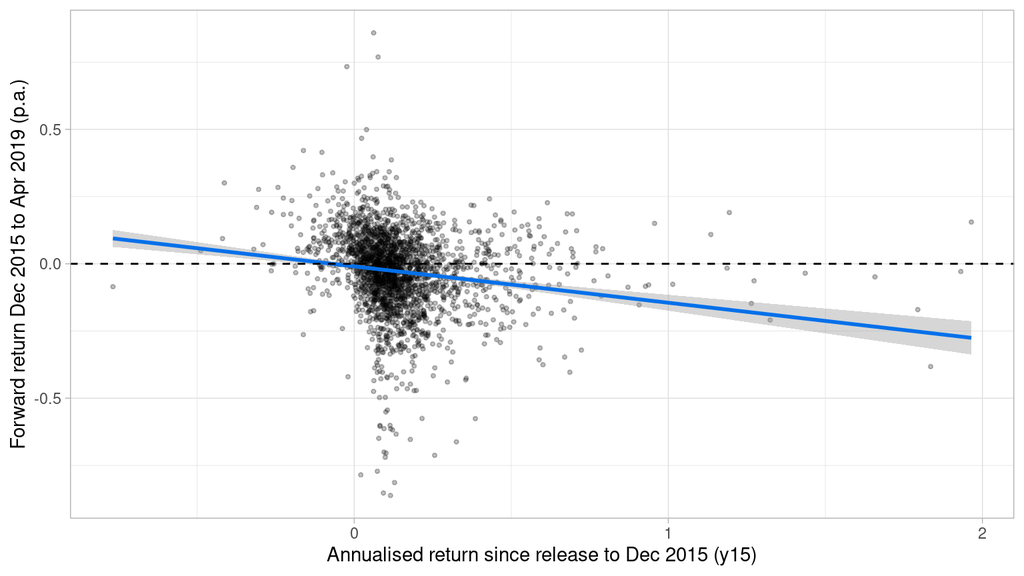

Past winners became losers: return since release to 2015 against the forward return 2015 to 2019

```r
sets %>% filter(!is.na(y_fwd)) %>%                                   # sets with a forward return
  ggplot(aes(x = y15, y = y_fwd)) +
  geom_point(alpha = 0.25, size = 0.8) +                             # one point per set
  geom_smooth(method = "lm", colour = "#0570EA") +                   # straight-line fit
  geom_hline(yintercept = 0, linetype = 2) +                         # zero return
  labs(x = "Annualised return since release to Dec 2015 (y15)", y = "Forward return Dec 2015 to Apr 2019 (p.a.)") +
  theme_light()
```

**Answer.** The LEGO premium did not continue: between December 2015 and April 2019 the median set’s price changed by -5.5% and an equal-weighted portfolio by 2.7% (simple returns, Section 0), and 56.1% of sets fell in price. Characteristics still carry some information about the forward return (out-of-sample R² up to 0.210). Adding the December 2015 price level, premium and return raises it to 0.396; on its own, the return already earned has a slope of -0.135 on the forward return. The correlation between the 2015 return and the 2015-2019 return is -0.162: the sets that had appreciated most did worst afterwards. With these features the best model reaches an out-of-sample R² of 0.396. Part of this is mechanical: a too-high December 2015 price quote raises the 2015 return and lowers the measured forward return at the same time, so the next section repeats the test on a window that does not contain the 2015 price.

## 3.1 Age as a number, target: forward return (y_fwd)

```r
# feature sets with age as a number
f_char_agen <- ~ theme_ml + size + age + pieces + pieces_sq + minifigs + log_retail
f_mom_agen  <- ~ theme_ml + size + age + pieces + pieces_sq + minifigs + log_retail + prem15 + log_p15 + y15

# three OLS fits on all sets, target y_fwd
fits3_agen <- list(`Characteristics (age as a number)`               = lm(update(f_char_agen, y_fwd ~ .), data = sets),
                   `Characteristics + 2015 price, premium, return` = lm(update(f_mom_agen,  y_fwd ~ .), data = sets),
                   `2015 return only`                              = lm(y_fwd ~ y15, data = sets))
```

OLS on all sets with a forward price. Target: forward return Dec 2015 to Apr 2019 (y_fwd, log, p.a.). Estimate (classical SE); *** p < 0.01, ** p < 0.05, * p < 0.1. Reference levels: theme Miscellaneous, size group 1

| Term | Characteristics (age as a number) | Characteristics + 2015 price, premium, return | 2015 return only |
| --- | --- | --- | --- |
| (Intercept) | 0.125** (0.0488) | 0.293*** (0.0427) | -0.00965** (0.00405) |
| theme_mlAdvanced models | -0.00201 (0.0391) | 0.0647* (0.0339) |  |
| theme_mlAgents | -0.139*** (0.0419) | -0.112*** (0.0362) |  |
| theme_mlArchitecture | 0.166*** (0.0389) | 0.182*** (0.0336) |  |
| theme_mlAtlantis | 0.0392 (0.0404) | -0.00188 (0.035) |  |
| theme_mlBatman | -0.164*** (0.0361) | -0.0722** (0.0314) |  |
| theme_mlBionicle | 0.0664** (0.0284) | 0.0736*** (0.0246) |  |
| theme_mlCars | 0.028 (0.0399) | 0.0373 (0.0345) |  |
| theme_mlCastle | 0.101*** (0.0302) | 0.101*** (0.0261) |  |
| theme_mlCity | -0.0151 (0.0282) | 0.0129 (0.0244) |  |
| theme_mlCreator | -0.0249 (0.0297) | -0.0215 (0.0256) |  |
| theme_mlFriends | -0.0676** (0.0306) | -0.0495* (0.0265) |  |
| theme_mlHarry Potter | 0.067** (0.0337) | 0.156*** (0.0293) |  |
| theme_mlHero factory | 0.0373 (0.0307) | 0.0828*** (0.0266) |  |
| theme_mlIndiana Jones | -0.0285 (0.0444) | 0.0807** (0.0386) |  |
| theme_mlLegends of China | -0.0788** (0.031) | -0.0811*** (0.0268) |  |
| theme_mlLord of the Rings | 0.0711* (0.0368) | 0.0601* (0.0318) |  |
| theme_mlNinjago | -0.00943 (0.0303) | 0.00906 (0.0262) |  |
| theme_mlPirates | 0.0629* (0.0343) | 0.0746** (0.0297) |  |
| theme_mlPower miners | -0.122*** (0.044) | -0.0426 (0.0381) |  |
| theme_mlSeasonal | 0.0267 (0.0321) | 0.0651** (0.0278) |  |
| theme_mlSpace | 0.0158 (0.0322) | -0.0096 (0.0279) |  |
| theme_mlStar Wars | 0.0185 (0.028) | 0.0423* (0.0242) |  |
| theme_mlSuper Heroes | -0.0377 (0.0347) | 0.0011 (0.03) |  |
| theme_mlTechnic | 0.0296 (0.0301) | 0.0328 (0.026) |  |
| theme_mlTeenage mutant ninja turtle | 0.018 (0.044) | -0.0069 (0.0381) |  |
| theme_mlThe Lego movie | 0.0116 (0.0426) | 0.00178 (0.0368) |  |
| theme_mlTrains | 0.0019 (0.0385) | 0.0722** (0.0334) |  |
| theme_mlOther | 0.0135 (0.0294) | 0.0425* (0.0254) |  |
| size2 | 0.00403 (0.0269) | 0.00586 (0.0232) |  |
| size3 | -0.0109 (0.0347) | -0.00895 (0.03) |  |
| size4 | -0.0147 (0.0416) | -0.0161 (0.0359) |  |
| age | -0.011*** (0.000749) | -0.00232*** (0.000845) |  |
| pieces | 6.62e-05 (4.34e-05) | 0.000159*** (3.77e-05) |  |
| pieces_sq | -1.69e-08** (7.96e-09) | -2.78e-08*** (6.89e-09) |  |
| minifigs | -0.00189 (0.0017) | -0.00304** (0.00147) |  |
| log_retail | -0.0324*** (0.00662) | -0.0842*** (0.00602) |  |
| prem15 |  | -0.152*** (0.00713) |  |
| log_p15 |  | aliased |  |
| y15 |  | -0.0288 (0.02) | -0.135*** (0.0173) |
| Sets (N) | 2271 | 2271 | 2271 |
| R squared | 0.179 | 0.387 | 0.026 |
| Adjusted R squared | 0.165 | 0.377 | 0.026 |
| F-test p-value | 1.74e-71 | 2.42e-206 | 7.87e-15 |

Non-dummy variables: classical vs heteroskedasticity-robust (HC1) tests

| Model | Term | Estimate | t | p | Sig. | t (HC1) | p (HC1) | Sig. (HC1) |
| --- | --- | --- | --- | --- | --- | --- | --- | --- |
| Characteristics (age as a number) | (Intercept) | 0.125 | 2.565 | 0.010 | ** | 2.673 | 0.008 | *** |
| Characteristics (age as a number) | age | -0.011 | -14.708 | 0.000 | *** | -12.703 | 0.000 | *** |
| Characteristics (age as a number) | pieces | 6.62e-05 | 1.525 | 0.127 |  | 1.625 | 0.104 |  |
| Characteristics (age as a number) | pieces_sq | -1.69e-08 | -2.129 | 0.033 | ** | -2.433 | 0.015 | ** |
| Characteristics (age as a number) | minifigs | -0.00189 | -1.113 | 0.266 |  | -1.109 | 0.268 |  |
| Characteristics (age as a number) | log_retail | -0.0324 | -4.904 | 0.000 | *** | -4.860 | 0.000 | *** |
| Characteristics + 2015 price, premium, return | (Intercept) | 0.293 | 6.860 | 0.000 | *** | 6.848 | 0.000 | *** |
| Characteristics + 2015 price, premium, return | age | -0.00232 | -2.741 | 0.006 | *** | -2.126 | 0.034 | ** |
| Characteristics + 2015 price, premium, return | pieces | 0.000159 | 4.212 | 0.000 | *** | 4.419 | 0.000 | *** |
| Characteristics + 2015 price, premium, return | pieces_sq | -2.78e-08 | -4.033 | 0.000 | *** | -4.708 | 0.000 | *** |
| Characteristics + 2015 price, premium, return | minifigs | -0.00304 | -2.066 | 0.039 | ** | -2.081 | 0.038 | ** |
| Characteristics + 2015 price, premium, return | log_retail | -0.0842 | -13.973 | 0.000 | *** | -12.429 | 0.000 | *** |
| Characteristics + 2015 price, premium, return | prem15 | -0.152 | -21.355 | 0.000 | *** | -13.835 | 0.000 | *** |
| Characteristics + 2015 price, premium, return | y15 | -0.0288 | -1.441 | 0.150 |  | -1.109 | 0.268 |  |
| Characteristics + 2015 price, premium, return | log_p15 | NA | NA | NA | aliased | NA | NA | aliased |
| 2015 return only | (Intercept) | -0.00965 | -2.381 | 0.017 | ** | -2.243 | 0.025 | ** |
| 2015 return only | y15 | -0.135 | -7.822 | 0.000 | *** | -6.601 | 0.000 | *** |

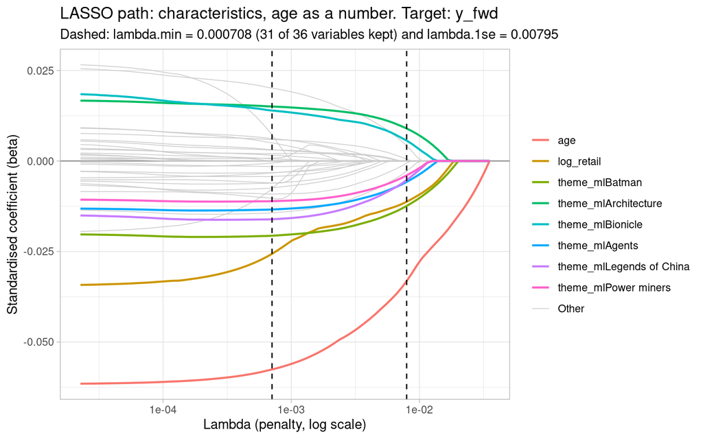

```r
# LASSO paths for the two feature sets
lp3_agen_char <- lasso_path(sets, "y_fwd", f_char_agen, "LASSO path: characteristics, age as a number. Target: y_fwd")
lp3_agen_mom  <- lasso_path(sets, "y_fwd", f_mom_agen,  "LASSO path: characteristics + 2015 price, premium, return. Target: y_fwd")
lp3_agen_char$plot
```

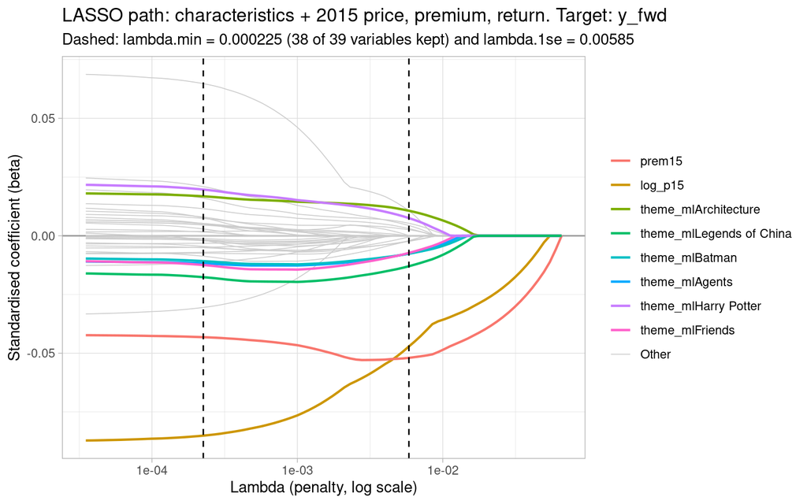

```r
lp3_agen_mom$plot
```

# 4. Experiment 2, clean window: return 2018 to 2019 with 2015 information

```r
oof_c_char <- cv_models(sets, "y_fwd2", f_full, rhs_full)   # same features, target Jan 2018 to Apr 2019
oof_c_mom  <- cv_models(sets, "y_fwd2", f_mom,  rhs_mom)

# one results table
res4 <- bind_rows(score(oof_c_char) %>% mutate(Features = "Characteristics"),
                  score(oof_c_mom)  %>% mutate(Features = "Characteristics + 2015 price, premium, return")) %>%
  select(Features, everything())
best4 <- res4 %>% filter(Model != "Naive (mean)") %>% slice_min(RMSE, n = 1)   # lowest error in this window
```

Held-out sets. Target: forward return January 2018 to April 2019, features as of December 2015

| Features | Model | OOS R2 | RMSE | Rank corr. | Median hit | Sign hit | Share y > 0 |
| --- | --- | --- | --- | --- | --- | --- | --- |
| Characteristics | LASSO | 0.075 | 0.187 | 0.306 | 0.620 | 0.608 | 0.425 |
| Characteristics | Elastic net | 0.075 | 0.187 | 0.306 | 0.620 | 0.607 | 0.425 |
| Characteristics | Ridge | 0.074 | 0.188 | 0.303 | 0.618 | 0.609 | 0.425 |
| Characteristics | Random forest | 0.064 | 0.189 | 0.306 | 0.618 | 0.611 | 0.425 |
| Characteristics | OLS | 0.064 | 0.189 | 0.302 | 0.623 | 0.608 | 0.425 |
| Characteristics | XGBoost | 0.058 | 0.189 | 0.296 | 0.609 | 0.608 | 0.425 |
| Characteristics | Tree | 0.042 | 0.191 | 0.273 | 0.596 | 0.610 | 0.425 |
| Characteristics | Naive (mean) | -0.001 | 0.195 | -0.032 | 0.495 | 0.560 | 0.425 |
| Characteristics + 2015 price, premium, return | Elastic net | 0.102 | 0.185 | 0.349 | 0.629 | 0.615 | 0.425 |
| Characteristics + 2015 price, premium, return | LASSO | 0.102 | 0.185 | 0.349 | 0.627 | 0.615 | 0.425 |
| Characteristics + 2015 price, premium, return | Ridge | 0.101 | 0.185 | 0.350 | 0.629 | 0.618 | 0.425 |
| Characteristics + 2015 price, premium, return | Random forest | 0.097 | 0.185 | 0.346 | 0.613 | 0.629 | 0.425 |
| Characteristics + 2015 price, premium, return | OLS | 0.092 | 0.186 | 0.346 | 0.624 | 0.624 | 0.425 |
| Characteristics + 2015 price, premium, return | XGBoost | 0.078 | 0.187 | 0.315 | 0.605 | 0.592 | 0.425 |
| Characteristics + 2015 price, premium, return | Tree | 0.034 | 0.192 | 0.268 | 0.587 | 0.595 | 0.425 |
| Characteristics + 2015 price, premium, return | Naive (mean) | -0.001 | 0.195 | -0.032 | 0.495 | 0.560 | 0.425 |

# 5. Investor view: sorting sets on a forecast made in advance

Sections 3 and 4 fit and score their models on the same window, so an investor could not have built them in advance, and picking the best model by its score on the same data would bias the result upwards. Here we use **one model fixed in advance**: OLS with all features, fitted on an earlier window and applied unchanged to a later one. The data hold no prices between release and December 2015 other than the retail price, so both windows come from the monthly 2018-2019 prices:

|  | Information date | Return measured |
| --- | --- | --- |
| Fitting window | January 2018 | February to August 2018 |
| Sorting window | August 2018 | September 2018 to April 2019 |

In both windows the return starts one month after the information date. An investor in August 2018 knew everything the model uses. Features: theme, size, age at the information date, pieces, minifigures, retail price, the premium over retail at the information date (`prem_now`) and the annualised return since release at that date (`y_since`).

```r
# the two windows
WIN_FIT  <- c(info = "2018-01-01", start = "2018-02-01", end = "2018-08-01")
WIN_SORT <- c(info = "2018-08-01", start = "2018-09-01", end = "2019-04-01")

# one row per set with the features at the information date and the return after it
make_window <- function(w){
  sets %>% select(id, theme, theme_ml, size, year, pieces, pieces_sq, minifigs, log_retail, p_retail) %>%
    inner_join(p_at(w[["info"]],  "p_info"),  by = "id") %>%          # price at the information date
    inner_join(p_at(w[["start"]], "p_start"), by = "id") %>%          # price when the return starts
    inner_join(p_at(w[["end"]],   "p_stop"),  by = "id") %>%          # price when the return ends
    mutate(age_now  = year(as.Date(w[["info"]])) + (month(as.Date(w[["info"]])) - 1) / 12 - year,   # age in years
           prem_now = log(p_info / p_retail),                         # log premium over retail at that date
           y_since  = prem_now / age_now,                             # annualised return since release
           h        = as.numeric(as.Date(w[["end"]]) - as.Date(w[["start"]])) / 365.25,   # length of the return window
           y        = log(p_stop / p_start) / h,                      # annualised log return
           R_hold   = p_stop / p_start - 1)                           # simple return over the window
}
win_fit  <- make_window(WIN_FIT)
win_sort <- make_window(WIN_SORT)

# fit OLS on the first window and predict the second; both windows share one dummy matrix
f_inv <- ~ theme_ml + size + age_now + pieces + pieces_sq + minifigs + log_retail + prem_now + y_since
both  <- bind_rows(win_fit %>% mutate(part = "fit"), win_sort %>% mutate(part = "sort"))
X_inv <- model.matrix(f_inv, data = both)[, -1, drop = FALSE]        # dummies without the intercept
is_fit <- both$part == "fit"
b_inv <- coef(lm.fit(cbind(1, X_inv[is_fit, ]), both$y[is_fit]))     # OLS on the first window
b_inv[is.na(b_inv)] <- 0                                             # collinear columns get weight 0
sort5 <- win_sort %>%
  mutate(pred = as.numeric(cbind(1, X_inv[!is_fit, ]) %*% b_inv),    # forecast for the second window
         Quintile = ntile(pred, 5))                                  # 1 = lowest forecast, 5 = highest

# wild cluster bootstrap p-value for the slope of y on x, with the null imposed
# weights "rademacher" (+1 or -1) or "webb" (six values, better with few clusters, Webb 2023)
wild_cluster_p <- function(y, x, cluster, B = 999, seed = SEED, weights = c("rademacher", "webb")){
  weights <- match.arg(weights)
  w_pts <- if (weights == "rademacher") c(-1, 1) else c(-sqrt(1.5), -1, -sqrt(0.5), sqrt(0.5), 1, sqrt(1.5))
  t_of <- function(yy){ f <- lm(yy ~ x); coef(f)[2] / sqrt(vcovCL(f, cluster = cluster)[2, 2]) }   # clustered t
  t_obs <- t_of(y)                                                   # t in the data
  f0 <- fitted(lm(y ~ 1)); e0 <- y - f0                              # fit and residuals under the null
  g <- as.integer(factor(cluster)); G <- max(g)                      # cluster index and number of clusters
  set.seed(seed)
  t_b <- replicate(B, t_of(f0 + e0 * sample(w_pts, G, replace = TRUE)[g]))   # one weight per cluster in each draw
  (1 + sum(abs(t_b) >= abs(t_obs))) / (B + 1)                        # never exactly 0
}

# average results per quintile
sorts <- sort5 %>% group_by(Quintile) %>%
  summarise(Sets = n(),
            `Mean forecast (p.a.)` = mean(pred),
            `Realised (p.a., log)` = mean(y),
            `Realised over the window (simple)` = mean(R_hold),       # mean of each set's simple return
            `Share positive` = mean(y > 0), .groups = "drop")
spread        <- sorts$`Realised (p.a., log)`[5] - sorts$`Realised (p.a., log)`[1]               # top minus bottom, annualised log
spread_simple <- sorts$`Realised over the window (simple)`[5] - sorts$`Realised over the window (simple)`[1]   # same in simple terms
rank5 <- cor(sort5$pred, sort5$y, method = "spearman")              # rank correlation of forecast and outcome

# test of top against bottom quintile, clustered by theme
tb5 <- sort5 %>% filter(Quintile %in% c(1, 5)) %>% mutate(top = as.numeric(Quintile == 5))
fit_tb <- lm(y ~ top, data = tb5)                                    # slope on top = the spread
t_cluster <- coef(fit_tb)["top"] / sqrt(vcovCL(fit_tb, cluster = tb5$theme)["top", "top"])
p_wild    <- wild_cluster_p(tb5$y, tb5$top, tb5$theme)               # +1/-1 weights
p_webb    <- wild_cluster_p(tb5$y, tb5$top, tb5$theme, weights = "webb")   # six-point weights
n_themes5 <- n_distinct(tb5$theme)                                   # clusters in the test

# buying the top quintile, against the selling fee.
# the break-even fee needs no fee data; the net return uses today's eBay fees as an example,
# which may differ from the fees in 2018-2019
FEE_EBAY  <- 0.136   # eBay final value fee, most categories (eBay Seller Center, October 2026)
FEE_FIXED <- 0.40    # eBay fee per order in USD, orders over $10 (same source)
q5 <- sort5 %>% filter(Quintile == 5)                                # top quintile
q5_raw       <- mean(q5$R_hold)                                      # its return before costs
q5_excess    <- q5_raw - mean(sort5$R_hold)                          # minus the average set
q5_breakeven <- q5_raw / (1 + q5_raw)                                # fee that uses up the gain
q5_net       <- mean((1 + q5$R_hold) * (1 - FEE_EBAY) - FEE_FIXED / q5$p_start - 1)   # after the fee share and the order fee
```

Quintiles of the OLS forecast fixed in advance. Sorting window: Sep 2018 to Apr 2019

| Quintile | Sets | Mean forecast (p.a.) | Realised (p.a., log) | Realised over the window (simple) | Share positive |
| --- | --- | --- | --- | --- | --- |
| 1 | 450 | -0.263 | -0.052 | -0.012 | 0.453 |
| 2 | 450 | -0.158 | 0.010 | 0.022 | 0.493 |
| 3 | 449 | -0.100 | 0.065 | 0.053 | 0.584 |
| 4 | 449 | -0.037 | 0.053 | 0.047 | 0.508 |
| 5 | 449 | 0.069 | 0.074 | 0.065 | 0.510 |

**Answer.** Sorted on a forecast an investor could have made in August 2018, the top quintile beat the bottom quintile by 7.7% over the 7-month window (simple returns; 6.5% against -1.2%), and the rank correlation between forecast and outcome is 0.119. The test uses 41 themes as clusters: theme-clustered t = 7.27, wild cluster bootstrap p ≤ 0.001, with Webb’s six-point weights p ≤ 0.001. The fitting window has no December and the sorting window includes Christmas 2018; this can shift the level of returns between windows, but the sort compares sets within the same window. The spread is not a strategy: LEGO sets cannot be sold short. The tradable leg is the top quintile, which earned 6.5% per set (equal-weighted), 3.0% more than the average set. **Break-even:** a selling fee above 6.1% of the sale price uses up that gain, whatever the fee schedule. As a scenario, today’s eBay fees (13.6% of the sale plus $0.40 per order; eBay Seller Center) would leave -10.6%, before shipping, the buyer’s costs and storage. The 2018-2019 fees, when eBay and PayPal charged sellers separately, are not verified here. *In annualised log terms, used by the models, the spread is 12.6% a year.*

# 6. Why a naive 2018 test gives 70% hit ratios

A natural first test is to train on the 2015 cross-section and “predict” the 2018-2019 prices of the same sets with the same target definition, the return since release. It gives hit ratios near 70%. This is not forecasting.

```r
# return since release measured at the last 2018-2019 price
tp <- sets %>% filter(!is.na(y_fwd)) %>%
  mutate(y_1819 = log(p_end / p_retail) /
           (year(date_end) - year + (month(date_end) - 12) / 12))   # divided by the age at that date
```

Persistence, not prediction

| Check | Value |
| --- | --- |
| Correlation: return since release in 2015 vs in 2019 | 0.537 |
| Median hit of the rule “rank 2019 like 2015” (no model) | 0.721 |
| Median hit of the same rule against the forward return | 0.408 |

**Answer.** The return since release measured in 2019 contains the return since release measured in 2015 plus three more years, so the two are correlated 0.537. A model that fits the 2015 cross-section therefore “predicts” the 2019 cross-section without any information about the future: ranking sets by their own 2015 return already gives a hit ratio of 72.1%, more than any model. Against the forward return the same rule scores 40.8%, below 50%, which is the mean reversion of Sections 3 and 4 seen from the other side. The lesson is the one from the course: the test target must not share information with the training target, and the benchmark must be the simplest rule that uses the same information.

# 7. Limitations

**Answer.** What the design can and cannot show.

- *Period.* All forward tests use December 2015 to April 2019. The forecast in Section 5 is made in advance, but both of its windows sit inside 2018-2019; the data hold no prices before 2015 to test an earlier window.
- *Returns.* Returns before costs. Up to 2015 the average set earned 14.8% a year as a mean annualised log return (median 11.4%); the paper’s 11% may use another definition. Neither is a net investment return.
- *Prices.* Monthly aggregates of eBay sales from BrickPicker’s price guide, “approximate” and “several months old” by the source’s own description (sheet “About the sample”). The 2018-2019 file matches the 2015 new-price level (Section 0.1), but its method is not documented.
- *Stale quotes.* The clean window (Section 4) removes the direct mechanical link through the 2015 price but only weakens it: a stale 2015 quote can still be in the January 2018 price.
- *Dependence.* Sets of one theme move together. Section 5 reports theme-clustered t-statistics with the 41 themes in the top and bottom quintiles as clusters, and wild cluster bootstraps with Rademacher and Webb weights, which are more reliable with few clusters (Cameron, Gelbach and Miller 2008; Webb 2023). With essentially one or two time periods, the effective sample in time is small.
- *Sample.* 29 sets have no 2018-2019 price and a few are dropped in 2015 (Section 0.1). These are probably the least traded, so the results lean towards liquid sets.
- *Models.* Ridge, LASSO and elastic net choose their penalty by cross-validation inside each training fold; the tree, random forest and XGBoost use fixed settings from the course. The model comparison is indicative.

# 8. Summary

Main results (held-out sets)

| Question | Model | OOS R2 | Rank corr. |
| --- | --- | --- | --- |
| 1a. Unseen sets (random folds), return to 2015 | XGBoost | 0.486 | 0.596 |
| 1a. Unseen sets (random folds), return to 2015 | Random forest | 0.486 | 0.640 |
| 1a. Unseen sets (random folds), return to 2015 | LASSO | 0.297 | 0.523 |
| 1a. Unseen sets (random folds), return to 2015 | OLS | 0.293 | 0.529 |
| 1b. Unseen themes, return to 2015 | Random forest | 0.401 | 0.511 |
| 1b. Unseen themes, return to 2015 | XGBoost | 0.400 | 0.512 |
| 1b. Unseen themes, return to 2015 | LASSO | 0.237 | 0.447 |
| 1b. Unseen themes, return to 2015 | OLS | 0.231 | 0.455 |
| 1c. Unseen release years, return to 2015 | Random forest | 0.164 | 0.502 |
| 1c. Unseen release years, return to 2015 | LASSO | 0.144 | 0.455 |
| 1c. Unseen release years, return to 2015 | OLS | 0.135 | 0.456 |
| 1c. Unseen release years, return to 2015 | XGBoost | 0.092 | 0.483 |
| 2a. Forward return 2015 to 2019 (same window) | Random forest | 0.396 | 0.659 |
| 2a. Forward return 2015 to 2019 (same window) | XGBoost | 0.386 | 0.644 |
| 2a. Forward return 2015 to 2019 (same window) | LASSO | 0.372 | 0.615 |
| 2a. Forward return 2015 to 2019 (same window) | OLS | 0.365 | 0.612 |
| 2b. Clean window 2018 to 2019 (same window) | LASSO | 0.102 | 0.349 |
| 2b. Clean window 2018 to 2019 (same window) | Random forest | 0.097 | 0.346 |
| 2b. Clean window 2018 to 2019 (same window) | OLS | 0.092 | 0.346 |
| 2b. Clean window 2018 to 2019 (same window) | XGBoost | 0.078 | 0.315 |

*Data:* Dobrynskaya and Kishilova, Mendeley Data v9hhs66vm3 (“DiB whole sample Dec 2015 prices”, “DiB whole sample Jan 2018 - Apr 2019 prices”); data description in the sheet “About the sample”. *Fees:* eBay Seller Center, https://www.ebay.com/sellercenter/selling/start-selling-on-ebay/seller-fees (accessed October 2026). *Methods:* Roberts et al. (2017), *Ecography* 40 (grouped cross-validation); Cameron, Gelbach and Miller (2008), *Review of Economics and Statistics* 90(3) (wild cluster bootstrap); Webb (2023), *Canadian Journal of Economics* (six-point weights); Getmansky, Lo and Makarov (2004), *JFE* (smoothed returns). *Code:* replication block from `LegoProject.R`; cross-validation by set and by group, forward targets, clean window, sorts on a forecast made in advance and the persistence check added. Models and metrics as in the course homeworks (Coqueret and Guida, Chapters 5 and 6).